# Hypothesis Testing (T Tests)

```python
import numpy as np
import pandas as pd
import scipy.stats as stats
import math
import warnings
import matplotlib.pyplot as plt
import seaborn as sns
```

```python
warnings.filterwarnings("ignore")
```

```python
df = pd.read_excel(r"D:\Data Science\DSML_UNext\DSML_Assignments\STATS\Assignment\Case Study_1 dataset.xlsx")
df
```

|  | GRIP | ARM | RATINGS | SIMS |
| --- | --- | --- | --- | --- |
| 0 | 105.5 | 80.5 | 31.8 | 1.18 |
| 1 | 106.5 | 93.0 | 39.8 | 0.94 |
| 2 | 94.0 | 81.0 | 46.8 | 0.84 |
| 3 | 90.5 | 33.5 | 52.2 | -2.45 |
| 4 | 104.0 | 47.5 | 31.2 | 1.00 |
| ... | ... | ... | ... | ... |
| 270 | 105.0 | 73.0 | 51.4 | -0.15 |
| 271 | 113.0 | 87.0 | 49.1 | -0.25 |
| 272 | 133.5 | 96.5 | 44.6 | 2.27 |
| 273 | 89.5 | 63.5 | 37.8 | -0.93 |
| 274 | 95.0 | 70.0 | 35.4 | -0.58 |

275 rows × 4 columns

```python
df.info()
```

```
<class 'pandas.core.frame.DataFrame'>
RangeIndex: 275 entries, 0 to 274
Data columns (total 4 columns):
 #   Column   Non-Null Count  Dtype
---  ------   --------------  -----
 0   GRIP     275 non-null    float64
 1   ARM      275 non-null    float64
 2   RATINGS  275 non-null    float64
 3   SIMS     275 non-null    float64
dtypes: float64(4)
memory usage: 8.7 KB
```

```python
df['GRIP']
```

```
0      105.5
1      106.5
2       94.0
3       90.5
4      104.0
       ...
270    105.0
271    113.0
272    133.5
273     89.5
274     95.0
Name: GRIP, Length: 275, dtype: float64
```

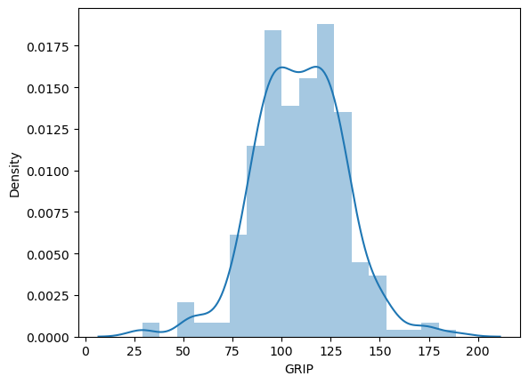

```python
sns.distplot(df['GRIP'])
```

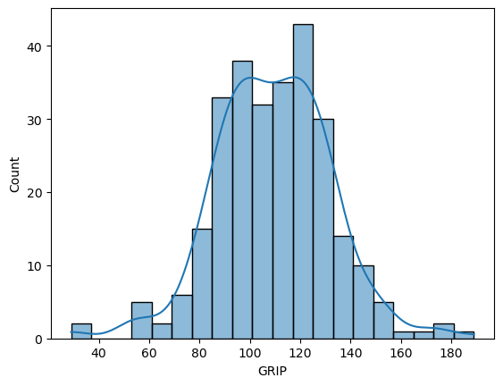

```python
sns.histplot(df['GRIP'], kde=True, bins=20)
```

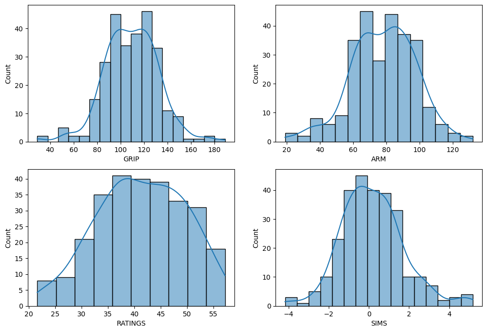

```python
plt.figure(figsize=(12,8))

for i in range(len(df.columns)):
    plt.subplot(2,2,i+1)
    column_name = df.columns[i]
    sns.histplot(df[column_name], kde=True)
```

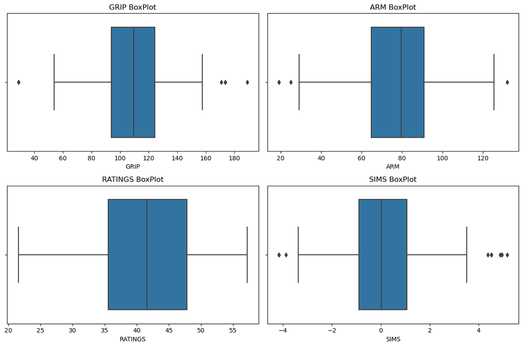

```python
plt.figure(figsize=(12,8))

for i in range(len(df.columns)):
    plt.subplot(2,2,i+1)
    column_name = df.columns[i]
    sns.boxplot(x=df[column_name])
    plt.title(f"{column_name} BoxPlot")
plt.tight_layout()
```

```python
# dict_wo_outliers = {}

# for i in range(len(df.columns)):
#     column_name = df.columns[i]

#     q1 = np.quantile(df[column_name], q=0.25)
#     q3 = np.quantile(df[column_name], q=0.75)
#     iqr = q3-q1

#     lower_thresh = q1-1.5*iqr
#     upper_thresh = q3+1.5*iqr
#     outliers = df[(df[column_name] < lower_thresh) | (df[column_name] > upper_thresh)]
#     dict_wo_outliers[column_name]= df[(df[column_name] > lower_thresh) & (df[column_name] < upper_thresh)]
# #   df_wo_outliers = df[(df[column_name] > lower_thresh) & (df[column_name] < upper_thresh)]

#     print(f"Lower Threshold for {column_name.title()}: {lower_thresh}.")
#     print(f"Upper Threshold for {column_name.title()}: {upper_thresh}.")
#     print(f"No. of outliers in {column_name.title()}: {len(outliers)}.\n")
```

```python
df
```

|  | GRIP | ARM | RATINGS | SIMS |
| --- | --- | --- | --- | --- |
| 0 | 105.5 | 80.5 | 31.8 | 1.18 |
| 1 | 106.5 | 93.0 | 39.8 | 0.94 |
| 2 | 94.0 | 81.0 | 46.8 | 0.84 |
| 3 | 90.5 | 33.5 | 52.2 | -2.45 |
| 4 | 104.0 | 47.5 | 31.2 | 1.00 |
| ... | ... | ... | ... | ... |
| 270 | 105.0 | 73.0 | 51.4 | -0.15 |
| 271 | 113.0 | 87.0 | 49.1 | -0.25 |
| 272 | 133.5 | 96.5 | 44.6 | 2.27 |
| 273 | 89.5 | 63.5 | 37.8 | -0.93 |
| 274 | 95.0 | 70.0 | 35.4 | -0.58 |

275 rows × 4 columns

```python
test = df['GRIP'].head(192)
```

```python
pop = df['GRIP']
```

```python
pop_mean = pop.mean()
pop_std = pop.std()
print(f"Population Mean: {pop_mean}")
print(f"Population Std: {pop_std}")
```

```
Population Mean: 109.22909090909091
Population Std: 22.78786391637592
```

```python
samp_mean = test.mean()
samp_std = test.std()
print(f"Sample Mean: {samp_mean}")
print(f"Sample Std: {samp_std}")
```

```
Sample Mean: 109.1875
Sample Std: 23.146387096091136
```

# One Sample T-Test

## Hypothesis Framing for 2 Sided T-test

- H0: The sample mean is equal to the population mean
- Ha: The sample mean is different from the population mean

```python
# Calculating the p-value.

alpha = 0.05
t_cal,pval = stats.ttest_1samp(test, popmean=109.23)

print(f"T calculated: {t_cal}.")
print(f"P Value: {pval}.\n")

if pval<alpha:
    print("There is sufficient statistical evidence to reject the Null Hypothesis.")
else:
    print("There is sufficient statistical evidence to fail to reject the Null Hypothesis.")

# The p_value returned is for both sides, so we compare it with the alpha, the t_statistic
# provides the value and the direction.
```

```
T calculated: -0.025442297846687438.
P Value: 0.9797287349952197.

There is sufficient statistical evidence to fail to reject the Null Hypothesis.
```

```python
# Calculating the t critical and compairing it with t calculated

lower_t = stats.t.ppf(q=0.025, df=187)
upper_t = stats.t.ppf(q=0.975, df=187)

print(f"Lower t value: {lower_t}.")
print(f"Upper t value: {upper_t}.\n")


if t_cal<lower_t:
    print("There is sufficient statistical evidence to reject the Null Hypothesis.")
else:
    print("There is sufficient statistical evidence to fail to reject the Null Hypothesis.")

# My t_statistic needs to be smaller than the lower_t for me to reject the H0.
```

```
Lower t value: -1.9727310334056907.
Upper t value: 1.9727310334056902.

There is sufficient statistical evidence to fail to reject the Null Hypothesis.
```

```python
# Calculating the t critical and compairing it with t calculated

lower_t = stats.t.ppf(q=0.025, df=187)
upper_t = stats.t.ppf(q=0.975, df=187)

print(f"Lower t value: {lower_t}.")
print(f"Upper t value: {upper_t}.\n")


if t_cal>upper_t:
    print("There is sufficient statistical evidence to reject the Null Hypothesis.")
else:
    print("There is sufficient statistical evidence to fail to reject the Null Hypothesis.")

# My t_statistic needs to be greater than my upper_t for me to reject the H0.
```

```
Lower t value: -1.9727310334056907.
Upper t value: 1.9727310334056902.

There is sufficient statistical evidence to fail to reject the Null Hypothesis.
```

#### Getting t_critical and p_critical

```python
# ppf method takes in the desired p_value/alpha and returns the corresponding critical t value.

lower_t, upper_t = stats.t.ppf(q=[0.025, 0.975], df=187)
print(f"Lower_t: {lower_t}, "
      f"Upper_t: {upper_t}")
```

```
Lower_t: -1.9727310334056907, Upper_t: 1.9727310334056902
```

```python
stats.t.ppf(q=0.9872, df=187)
```

```
2.2502191568130088
```

```python
# cdf method takes in the desired t/z value and returns the corresponding p value/area under
# the curve (left side).

p_value1 = stats.t.cdf(x=1, df=187)
p_value2 = stats.t.cdf(x=-2, df=187)

print(f"First p value:{p_value1}, Second p value= {p_value2}")
```

```
First p value:0.8406986312388476, Second p value= 0.02347373457195304
```

## One Sample One Sided T-test

### Right Tailed Test

- H0: The sample mean is lesser than or equal to the population mean.
- Ha: The sample mean is greater than the population mean.

```python
# Using p value method

t_cal, pval = stats.ttest_1samp(test, popmean=108.82, alternative='greater')


print(f"T calculated: {t_cal}.")
print(f"P Value: {pval}.\n")

if pval<alpha:
    print("There is sufficient statistical evidence to reject the Null Hypothesis.")
else:
    print("There is sufficient statistical evidence to fail to reject the Null Hypothesis.")

# this test returns the p value on the right side of the curve,
# to get the left side, either subtract from one or get it from the t.cdf method
```

```
T calculated: 0.22000104608604545.
P Value: 0.41305264956400145.

There is sufficient statistical evidence to fail to reject the Null Hypothesis.
```

```python
# Proving the above statement

p_value = stats.t.cdf(x=0.22000104608604545, df=187)

print(f"Area on the left side: {p_value}")
print(f"Area on the right side: {1-p_value}") # this is returned above
```

```
Area on the left side: 0.5869448392667665
Area on the right side: 0.41305516073323345
```

```python
# Using t-score method

t_cri = stats.t.ppf(q=0.95, df=187)

print(f"T critical is {t_cri}.\n")

if t_cal>t_cri:
    print("There is sufficient statistical evidence to reject the Null Hypothesis.")
else:
    print("There is sufficient statistical evidence to fail to reject the Null Hypothesis.")

# My t_statistic needs to be greater than the t_critical for me to reject the H0.
```

```
T critical is 1.6530428889457807.

There is sufficient statistical evidence to fail to reject the Null Hypothesis.
```

### Left Tailed Test

- H0: The sample mean is greater than or equal to the population mean.
- Ha: The sample mean is lesser than the population mean.

```python
# Using p value method

t_cal, pval = stats.ttest_1samp(test, popmean=108.82, alternative='less')


print(f"T calculated: {t_cal}.")
print(f"P Value: {pval}.\n")

if pval<alpha:
    print("There is sufficient statistical evidence to reject the Null Hypothesis.")
else:
    print("There is sufficient statistical evidence to fail to reject the Null Hypothesis.")

# this test returns the p value on the left side of the curve,
# to get the right side, either subtract from one or get it from the t.cdf method
```

```
T calculated: 0.22000104608604545.
P Value: 0.5869473504359985.

There is sufficient statistical evidence to fail to reject the Null Hypothesis.
```

```python
p_value = stats.t.cdf(x=0.22000104608604545, df=187)

print(f"Area on the left side: {p_value}") # this is returned above
print(f"Area on the right side: {1-p_value}")
```

```
Area on the left side: 0.5869448392667665
Area on the right side: 0.41305516073323345
```

```python
# Using t score method

t_cri = stats.t.ppf(q=0.05, df=187)

print(f"T critical is {t_cri}.\n")

if t_cal<t_cri:
    print("There is sufficient statistical evidence to reject the Null Hypothesis.")
else:
    print("There is sufficient statistical evidence to fail to reject the Null Hypothesis.")

# My t_statistic needs to be smaller than the t_critical for me to reject the H0.
```

```
T critical is -1.6530428889457813.

There is sufficient statistical evidence to fail to reject the Null Hypothesis.
```

- Since all the test results are the same i.e We fail to reject the Null Hypothesis.
- This means that we can say the sample mean is the same as the population mean with a significance level of 5%.

#### Calculating Confidence Intervals

```python
se = test.std()/math.sqrt(len(test))

lower_range, upper_range = stats.t.interval(alpha=0.95, df=187, loc=test.mean(), scale=se)

print(f"Lower Range: {lower_range}.")
print(f"Upper Range: {upper_range}.")
```

```
Lower Range: 105.89215814742964.
Upper Range: 112.48284185257036.
```

### Two-Sample (Independent) T-Test

#### Hypothesis

- H0: Arm Data and Grip have the same mean.
- HA: Arm Data and Grip have different mean.

```python
arm_data = df['ARM']
```

```python
arm_data_test = arm_data.head(188)
```

```python
t_cal, pval = stats.ttest_ind(a=test, b=arm_data_test, equal_var=False)

print(f"T statistic: {t_cal}.")
print(f"P Value: {pval}.\n")

if pval<alpha:
    print("There is sufficient statistical evidence to reject the Null Hypothesis.")
else:
    print("There is sufficient statistical evidence to fail to reject the Null Hypothesis.")
```

```
T statistic: 13.987657554380974.
P Value: 4.715276985781433e-36.

There is sufficient statistical evidence to reject the Null Hypothesis.
```

- Since the p value is significantly less than the alpha value, we can reject the null hypothesis and conclude that the arm and grip data have significantly different means.

### Paired T-Test

#### Hypothesis

- H0: There is no difference between the weights before and after the diet.
- HA: There is a difference between the weights before and after the diet.

```python
np.random.seed(11)

before = stats.norm.rvs(scale=30, loc=250, size=100)
after = before + stats.norm.rvs(scale=5, loc=-1.25, size=100)

weight_df = pd.DataFrame({'weight before': before,
                          'weight after': after,
                          'weight change': after-before
                        })

weight_df.head()
```

|  | weight before | weight after | weight change |
| --- | --- | --- | --- |
| 0 | 302.483642 | 305.605006 | 3.121364 |
| 1 | 241.417810 | 240.526071 | -0.891739 |
| 2 | 235.463046 | 226.017788 | -9.445258 |
| 3 | 170.400443 | 165.913930 | -4.486513 |
| 4 | 249.751461 | 252.590309 | 2.838848 |

```python
t_cal, pval = stats.ttest_rel(a=weight_df['weight before'], b=weight_df['weight after'])

print(f"T statistic: {t_cal}.")
print(f"P Value: {pval}.\n")

if pval<alpha:
    print("There is sufficient statistical evidence to reject the Null Hypothesis.")
else:
    print("There is sufficient statistical evidence to fail to reject the Null Hypothesis.")
```

```
T statistic: 2.5720175998568284.
P Value: 0.011596444318439857.

There is sufficient statistical evidence to reject the Null Hypothesis.
```

##### This implies there is a significant weight change before and after the implementation of a new diet.

## Paired t-test, one-sided (left)

```python
alpha=0.05
t_cal, pval = stats.ttest_rel(a=weight_df['weight before'], b=weight_df['weight after'],
                              alternative='less')

print(f"T statistic: {t_cal}.")
print(f"P Value: {pval}.\n")

if pval<alpha:
    print("There is sufficient statistical evidence to reject the Null Hypothesis.")
else:
    print("There is sufficient statistical evidence to fail to reject the Null Hypothesis.")
```

```
T statistic: 2.5720175998568284.
P Value: 0.99420177784078.

There is sufficient statistical evidence to fail to reject the Null Hypothesis.
```

```python
# Getting the t value for the alpha 0.05

t_cri = stats.t.ppf(q=0.05, df=99)

print(f"T critical: {t_cri}")
```

```
T critical: -1.6603911559963902
```

```python
if t_cal<t_cri:
    print("There is sufficient statistical evidence to reject the null hypothesis.")
else:
    print("There is sufficient statistical evidence to fail to reject the null hypothesis.")
```

```
There is sufficient statistical evidence to fail to reject the null hypothesis.
```

## Paired t-test, one-sided (right)

```python
t_cal, pval = stats.ttest_rel(a=before, b=after, alternative='greater')

print(f"T statistic: {t_cal}.")
print(f"P Value: {pval}.\n")

if pval<alpha:
    print("There is sufficient statistical evidence to reject the Null Hypothesis.")
else:
    print("There is sufficient statistical evidence to fail to reject the Null Hypothesis.")
```

```
T statistic: 2.5720175998568284.
P Value: 0.0057982221592199285.

There is sufficient statistical evidence to reject the Null Hypothesis.
```

```python
# Getting the t value for the alpha 0.95

stats.t.ppf(q=0.95, df=99)
```

```
1.6603911559963895
```

## MY UNDERSTANDING

#### So essentially in python the 2 sided, left side and right side methods work similarly.

- For a 2 sided test the code is
  - stats.ttest_1samp or stats.ttest_ind or stats.ttest_rel
  - but they all return a pvalue for both side(area under both ends of the curve) .
- For a left tailed test the code is
  - stats.ttest_1samp or stats.ttest_ind or stats.ttest_rel (..... alternative='less')
  - but they all return a pvalue for the left side (area under the left side of the curve) .
- For a right tailed test the code is
  - stats.ttest_1samp or stats.ttest_ind or stats.ttest_rel (..... alternative='greater')
  - but they all return a pvalue for the right side (area under the right side of the curve) .